# Biostat 274 Homework 4

Due Friday, Mar 6, 2026 @ 11:59PM

Author

Published

March 9, 2026

## 1 Support vector machines (SVMs) on the `Carseats` data set (30pts)

Follow the machine learning workflow to train support vector classifier (same as SVM with linear kernel), SVM with polynomial kernel (tune the degree and regularization parameter $C$), and SVM with radial kernel (tune the scale parameter $\gamma$ and regularization parameter $C$) for classifying `Sales<=8` versus `Sales>8`. Use the same seed as in your HW4 for the initial test/train split and compare the final test AUC and accuracy to those methods you tried in HW4.

## 2 Signed distance

Let
$$f(X) = \beta_0 + \beta_1 X_1 + \cdots + \beta_p X_p = \beta_0 + \beta^T X.$$
Then $f(X)=0$ defines a hyperplane in $\mathbb{R}^p$. Show that $f(x)$ is proportional to the signed distance of a point $x$ to the hyperplane $f(X) = 0$.

## 3 Dropout learning

Let $(x_i, y_i)$ for $i=1,\dots,n$ with $x_i \in \mathbb{R}^p$ and $y_i \in \mathbb{R}$. Consider a linear predictor
$$f_\beta(x) = x^\top \beta$$

and squared loss
$$\ell(y, f) = \tfrac12 (y-f)^2.$$

Let $\phi \in (0,1)$ be the **drop probability** and $q = 1-\phi$ the **keep probability**. Define inverted dropout on the input features via an i.i.d. Bernoulli mask
$$m_i \in \{0,1\}^p,\qquad m_{ij}\sim \text{Bernoulli}(q),$$

and the dropped input
$$\tilde x_i = \frac{m_i}{q}\odot x_i,$$
where $\odot$ denotes elementwise product.

### 3.1 (a) Scaling.

Show that $\mathbb{E}[\tilde x_i]=x_i$ (expectation over the dropout mask).
$$\mathbb{E}[\tilde x_i] = \mathbb{E}\left[\frac{m_i}{q}\odot x_i\right] = \frac{1}{q} \odot x_i \odot \mathbb{E}[m_i] = x_i.$$

### 3.2 (b) Expected dropout objective.

Define
$$\mathcal{L}_{\text{drop}}(\beta) = \sum_{i=1}^n \mathbb{E}_{m_i}\left[\tfrac12\left(y_i - \tilde x_i^\top \beta\right)^2\right].$$

Show that
$$\mathcal{L}_{\text{drop}}(\beta)
=
\sum_{i=1}^n \tfrac12\left(y_i - x_i^\top \beta\right)^2
+
\frac{\phi}{2(1-\phi)}\sum_{i=1}^n \sum_{j=1}^p \beta_j^2 x_{ij}^2.$$

**Hint:** expand $\left(y_i - \tilde x_i^\top \beta\right)^2$ and use $\mathbb{E}[\tilde x_i]=x_i$ plus $\mathrm{Var}(\tilde x_{ij}) = x_{ij}^2\,\mathrm{Var}(m_{ij}/q)$.

### 3.3 (c) When does it look like ridge?

Suppose features are standardized so that $\frac{1}{n}\sum_{i=1}^n x_{ij}^2 \approx 1$ for each $j$. Explain why the extra term in (b) is approximately proportional to $\|\beta\|_2^2$ and identify an “effective” ridge strength in terms of $\phi$ (up to your convention for sum vs mean loss).

### 3.4 (d) Short interpretation.

Explain why “dropout $\approx$ ridge” is only an analogy in deep networks, but why dropout still tends to reduce reliance on any single unit/feature.

## 4 Ridge and data augmentation

Again consider $f_\beta(x)=x^\top\beta$ and squared loss. Define a **Gaussian augmentation** of covariates:
$$x_i^\star = x_i + \epsilon_i,\qquad \epsilon_i\sim N(0, \tau^2 I_p),\qquad y_i^\star = y_i.$$

### 4.1 (a) Augmentation implies ridge.

Show:
$$\sum_{i=1}^n \mathbb{E}_{\epsilon_i}\Big[\tfrac12\left(y_i - (x_i^\star)^\top\beta\right)^2\Big]
=
\sum_{i=1}^n \tfrac12\left(y_i - x_i^\top\beta\right)^2
+
\frac{n\tau^2}{2}\|\beta\|_2^2.$$

### 4.2 (b) General covariance.

If $\epsilon_i\sim N(0,\Sigma)$, what penalty replaces $\|\beta\|_2^2$? (Write the penalty in a compact matrix form.)
$$\sum_{i=1}^n \mathbb{E}_{\epsilon_i}\Big[\tfrac12\left(y_i - (x_i^\star)^\top\beta\right)^2\Big]
=
\sum_{i=1}^n \tfrac12\left(y_i - x_i^\top\beta\right)^2
+
\frac{n}{2}\beta^\top \Sigma \beta.$$

## 5 Pretain, finetune, regularize: CIFAR-10 cats vs dogs

### 5.1 Data

Use CIFAR-10 and keep only the two classes:

- **cat = 3**, **dog = 5** (Keras label IDs).

### 5.2 Model

- Base: `MobileNetV2(weights="imagenet", include_top=FALSE)` (frozen).
- Head: `GlobalAveragePooling2D` + optional Dense(hidden) + Dropout + Dense(1, sigmoid).
- Resize from $32\times32$ to $96\times96$ inside the model using `layer_resizing()`.

### 5.3 Setup

- Load Keras and set random seed (adjust if needed for your setup):

```r
# Install once if needed:
# install.packages("keras3")
# keras3::install_keras()   # installs Python env + TensorFlow (once)

library(keras3)
use_backend("tensorflow")
set_random_seed(1)
```

- Load CIFAR-10, keep cats vs dogs, create splits

```r
cifar <- dataset_cifar10(convert = TRUE)

x_train <- cifar$train$x
y_train <- as.integer(cifar$train$y[,1])

x_test  <- cifar$test$x
y_test  <- as.integer(cifar$test$y[,1])

# Convert to channels_last if needed: (n, 3, 32, 32) -> (n, 32, 32, 3)
if (length(dim(x_train)) == 4 && dim(x_train)[2] == 3) {
  x_train <- aperm(x_train, c(1,3,4,2))
  x_test  <- aperm(x_test,  c(1,3,4,2))
}

# Keep cat=3 and dog=5
cls_cat <- 3L
cls_dog <- 5L

keep_tr <- y_train %in% c(cls_cat, cls_dog)
keep_te <- y_test  %in% c(cls_cat, cls_dog)



x_train <- x_train[keep_tr,,,,drop=FALSE]
y_train <- y_train[keep_tr]

x_test  <- x_test[keep_te,,,,drop=FALSE]
y_test  <- y_test[keep_te]

# Map labels: cat->0, dog->1
y_train <- ifelse(y_train == cls_dog, 1, 0)
y_test  <- ifelse(y_test  == cls_dog, 1, 0)

balanced_subsample <- function(x, y, n_per_class) {
  # ensure y is a vector, not an (n,1) matrix
  if (is.matrix(y)) y <- y[,1]
  y <- as.integer(y)

  i0 <- which(y == 0)
  i1 <- which(y == 1)

  stopifnot(length(i0) >= n_per_class, length(i1) >= n_per_class)

  i0 <- sample(i0, n_per_class)
  i1 <- sample(i1, n_per_class)
  idx <- sample(c(i0, i1))

  list(
    x = x[idx, , , , drop = FALSE],   # <-- 4D slice
    y = y[idx]
  )
}

# CPU-friendly default sizes (adjust if needed)
train_small <- balanced_subsample(x_train, y_train, n_per_class = 1000)
test_small  <- balanced_subsample(x_test,  y_test,  n_per_class = 500)

x <- train_small$x; y <- train_small$y
x_te <- test_small$x; y_te <- test_small$y

# Train/val split
set.seed(1)
n <- dim(x)[1]
val_n <- floor(0.2 * n)
val_idx <- sample(seq_len(n), val_n)
tr_idx  <- setdiff(seq_len(n), val_idx)

x_tr <- x[tr_idx,,,,drop=FALSE]; y_tr <- y[tr_idx]
x_va <- x[val_idx,,,,drop=FALSE]; y_va <- y[val_idx]

c(n_train = dim(x_tr)[1], n_val = dim(x_va)[1], n_test = dim(x_te)[1])
```

```
n_train   n_val  n_test
   1600     400    1000
```

— Build a pretrained model (MobileNetV2 frozen + head) - Example code to build a model with optional hidden layer, dropout, L2, and augmentation.

```r
build_model <- function(img = 96L,
                        hidden = 0L,
                        dropout_rate = 0,
                        l2 = 0,
                        augment = FALSE) {

  base <- application_mobilenet_v2(
    input_shape = c(img, img, 3),
    include_top = FALSE,
    weights = "imagenet"
  )
  base$trainable <- FALSE  # freeze base

  inputs <- keras_input(shape = c(32, 32, 3))

  x <- inputs |>
    layer_resizing(height = img, width = img) |>
    # MobileNetV2-style scaling to [-1,1]
    layer_rescaling(scale = 1/127.5, offset = -1)

  if (augment) {
    x <- x |>
      layer_random_flip("horizontal") |>
      layer_random_translation(height_factor = 0.05, width_factor = 0.05)
  }

  # Run frozen base in inference mode (BatchNorm stability)
  x <- x |>
    base(training = FALSE) |>
    layer_global_average_pooling_2d()

  if (hidden > 0) {
    x <- x |>
      layer_dense(
        units = hidden,
        activation = "relu",
        kernel_regularizer = if (l2 > 0) regularizer_l2(l2) else NULL
      )
  }

  if (dropout_rate > 0) {
    x <- x |> layer_dropout(rate = dropout_rate)
  }

  outputs <- x |>
    layer_dense(
      units = 1,
      activation = "sigmoid",
      kernel_regularizer = if (l2 > 0) regularizer_l2(l2) else NULL
    )

  model <- keras_model(inputs, outputs)

  model |> compile(
    optimizer = optimizer_adam(learning_rate = 1e-3),
    loss = loss_binary_crossentropy(from_logits = FALSE),
    metrics = list(
      metric_binary_accuracy(name = "acc"),
      metric_auc(name = "auc", from_logits = FALSE)
    )
  )

  model
}
```

— Baseline run (no dropout, no L2, no augmentation)

```r
model0 <- build_model(hidden = 0L, dropout_rate = 0, l2 = 0, augment = FALSE)

hist0 <- model0 |> fit(
  x_tr, y_tr,
  validation_data = list(x_va, y_va),
  epochs = 10,
  batch_size = 32,
  callbacks = list(callback_early_stopping(patience = 2, restore_best_weights = TRUE)),
  verbose = 2
)
```

```
50/50 - 4s - 75ms/step - acc: 0.6956 - auc: 0.7762 - loss: 0.5652 - val_acc: 0.7800 - val_auc: 0.8524 - val_loss: 0.4804
50/50 - 2s - 43ms/step - acc: 0.8363 - auc: 0.9160 - loss: 0.3674 - val_acc: 0.8125 - val_auc: 0.8834 - val_loss: 0.4305
50/50 - 2s - 43ms/step - acc: 0.8612 - auc: 0.9378 - loss: 0.3195 - val_acc: 0.8225 - val_auc: 0.8944 - val_loss: 0.4124
50/50 - 2s - 43ms/step - acc: 0.8788 - auc: 0.9494 - loss: 0.2907 - val_acc: 0.8325 - val_auc: 0.8998 - val_loss: 0.4039
50/50 - 2s - 43ms/step - acc: 0.8850 - auc: 0.9573 - loss: 0.2698 - val_acc: 0.8375 - val_auc: 0.9036 - val_loss: 0.3993
50/50 - 2s - 43ms/step - acc: 0.8938 - auc: 0.9630 - loss: 0.2532 - val_acc: 0.8400 - val_auc: 0.9062 - val_loss: 0.3967
50/50 - 2s - 43ms/step - acc: 0.9000 - auc: 0.9674 - loss: 0.2393 - val_acc: 0.8375 - val_auc: 0.9075 - val_loss: 0.3953
50/50 - 2s - 43ms/step - acc: 0.9087 - auc: 0.9710 - loss: 0.2273 - val_acc: 0.8375 - val_auc: 0.9089 - val_loss: 0.3947
50/50 - 2s - 43ms/step - acc: 0.9137 - auc: 0.9741 - loss: 0.2167 - val_acc: 0.8450 - val_auc: 0.9095 - val_loss: 0.3947
50/50 - 2s - 44ms/step - acc: 0.9219 - auc: 0.9768 - loss: 0.2071 - val_acc: 0.8450 - val_auc: 0.9102 - val_loss: 0.3952
```

```r
eval0 <- model0 |> evaluate(x_te, y_te, verbose = 0)
eval0
```

```
$acc
[1] 0.853

$auc
[1] 0.929732

$loss
[1] 0.3461495
```

- Baseline model: learning curves

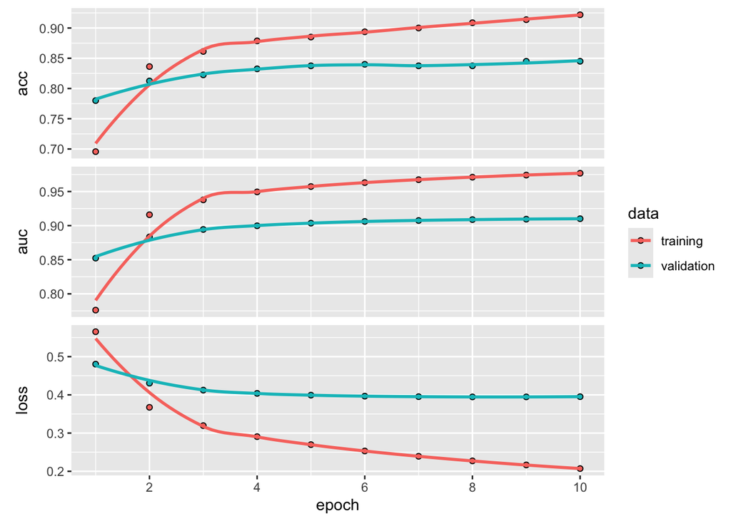

```r
plot(hist0)
```

— Baseline model: Brier score + calibration curve

```r
# predicted probabilities on test set
p_te <- as.numeric(model0 |> predict(x_te, verbose = 0))

brier <- mean((p_te - y_te)^2)
brier
```

```
[1] 0.1064637
```

```r
# Simple 10-bin calibration table
calibration_table <- function(p, y, bins = 10) {
  stopifnot(length(p) == length(y))
  breaks <- seq(0, 1, length.out = bins + 1)
  bin <- cut(p, breaks = breaks, include.lowest = TRUE)
  df <- data.frame(p = p, y = y, bin = bin)
  agg_p <- tapply(df$p, df$bin, mean)
  agg_y <- tapply(df$y, df$bin, mean)
  n_bin <- as.integer(table(df$bin))
  out <- data.frame(
    bin = names(agg_p),
    n = n_bin,
    mean_pred = as.numeric(agg_p),
    mean_obs  = as.numeric(agg_y)
  )
  out
}

cal0 <- calibration_table(p_te, y_te, bins = 10)
cal0
```

```
         bin   n  mean_pred   mean_obs
1    [0,0.1] 317 0.02880049 0.06309148
2  (0.1,0.2]  84 0.14005756 0.21428571
3  (0.2,0.3]  49 0.24712646 0.30612245
4  (0.3,0.4]  40 0.33958517 0.37500000
5  (0.4,0.5]  41 0.44081354 0.51219512
6  (0.5,0.6]  38 0.55332683 0.57894737
7  (0.6,0.7]  31 0.65527672 0.58064516
8  (0.7,0.8]  42 0.74296418 0.85714286
9  (0.8,0.9]  76 0.85274452 0.86842105
10   (0.9,1] 282 0.97473347 0.95390071
```

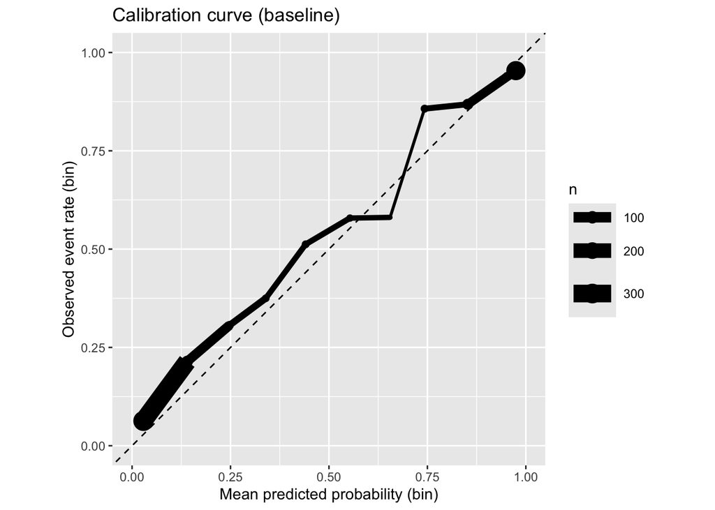

```r
# Optional plot (recommended)
# install.packages("ggplot2") if needed
library(ggplot2)

ggplot(cal0, aes(x = mean_pred, y = mean_obs, size = n)) +
  geom_point() +
  geom_line() +
  geom_abline(slope = 1, intercept = 0, linetype = "dashed") +
  coord_equal(xlim = c(0,1), ylim = c(0,1)) +
  labs(x = "Mean predicted probability (bin)",
       y = "Observed event rate (bin)",
       title = "Calibration curve (baseline)")
```

### 5.4 Regularization comparison (dropout vs L2 vs augmentation)

Train **four** models with the same train/val/test split:

- M0: none (baseline)
- M1: dropout only (e.g., $\phi=0.2$ so `dropout_rate=0.2`)
- M2: L2 only (e.g., `l2=1e-4`)
- M3: augmentation only (`augment=TRUE`)

**Task 1**: Report a small results table with test `acc`, test `auc`, and test Brier score.

### 5.5 Fine-tuning the pretrained CNN

So far, MobileNetV2 was **frozen** and only the head was trained. Now you will **fine-tune** a small number of layers near the end of the pretrained base using a **small learning rate**.

**Task 2** Write a small table to ompare baseline (frozen base) vs fine-tuned (partially unfrozen base) vs Regularized and report

- test accuracy and AUC
- test Brier score
- calibration curve shape

Then answer the following questions:

- Did fine-tuning improve test accuracy/AUC? Did it improve or worsen calibration (Brier + calibration curve)?
- If it got worse, give 2 plausible reasons (overfitting, too many layers unfrozen, learning rate too large, small data, etc.).
- Report exactly what you fine-tuned: `n_unfreeze`, learning rate, and number of epochs.

> **CPU note:** Fine-tuning is slower than head-only training. If it is too slow, set `n_unfreeze = 10` and `epochs = 2`.
- Helper code: locate the MobileNetV2 base inside the full model

```r
get_mobilenet_base <- function(model) {
  nm <- sapply(model$layers, function(L) L$name)
  idx <- which(grepl("mobilenet", nm, ignore.case = TRUE))
  if (length(idx) == 0) stop("Could not find a MobileNet layer in model$layers.")
  model$get_layer(nm[idx[1]])
}
```

- Helper code: unfreeze last `n_unfreeze` layers (and keep BatchNorm frozen) and fine tune with a smaller learning rate, etc.

```r
set_finetune <- function(model, n_unfreeze = 20, freeze_batchnorm = TRUE) {
  base <- get_mobilenet_base(model)
  base$trainable <- TRUE

  L <- base$layers
  nL <- length(L)
  n_unfreeze <- min(n_unfreeze, nL)

  # Freeze all but the last n_unfreeze layers
  for (i in seq_len(nL - n_unfreeze)) {
    L[[i]]$trainable <- FALSE
  }

  # Recommended on small data: keep BatchNorm frozen
  if (freeze_batchnorm) {
    for (i in seq_len(nL)) {
      if (grepl("batch_normalization", L[[i]]$name, ignore.case = TRUE)) {
        L[[i]]$trainable <- FALSE
      }
    }
  }

  invisible(model)
}
```

- Helper code: Fine-tune and evaluate

```r
# Unfreeze last layers
set_finetune(model0, n_unfreeze = 20, freeze_batchnorm = TRUE)

# After changing trainable flags, re-compile with a smaller learning rate
model0 |> compile(
  optimizer = optimizer_adam(learning_rate = 1e-5),
  loss = loss_binary_crossentropy(from_logits = FALSE),
  metrics = list(
    metric_binary_accuracy(name = "acc"),
    metric_auc(name = "auc", from_logits = FALSE)
  )
)

hist_ft <- model0 |> fit(
  x_tr, y_tr,
  validation_data = list(x_va, y_va),
  epochs = 5,
  batch_size = 32,
  callbacks = list(callback_early_stopping(patience = 1, restore_best_weights = TRUE)),
  verbose = 2
)

eval_ft <- model0 |> evaluate(x_te, y_te, verbose = 0)
eval_ft
```

[output not shown]